# Decomposition Techniques for Social Epidemiology: Why and How

Danish Epidemiological Society Conference

Sam Harper

2026-09-22

## Social Epidemiologic Aims

**Descriptive**  
Existence of social differences in health

**Etiologic**  
Causes of social differences in health

**Interventions**  
Policies and programs to address causes

## Enough already?

> Nevertheless, health inequalities are socially produced, and therefore, also potentially avoidable. However, effective political interventions require a scientific understanding of the causal mechanisms generating the strong and persistent correlations between social conditions and health outcomes.

[figure not shown]

### How can we find out?

Eikemo and Øversveen (2019)

## Decomposition: from description to explanation

**What changed?**  
Explaining growing or shrinking gaps

**Which ‘components’?**  
Bridge between descriptive and causal

**What if?**  
Techniques often involve ‘counterfactual’ scenarios

## Danish smoking has declined from 21% (2010) to 11% (2025)

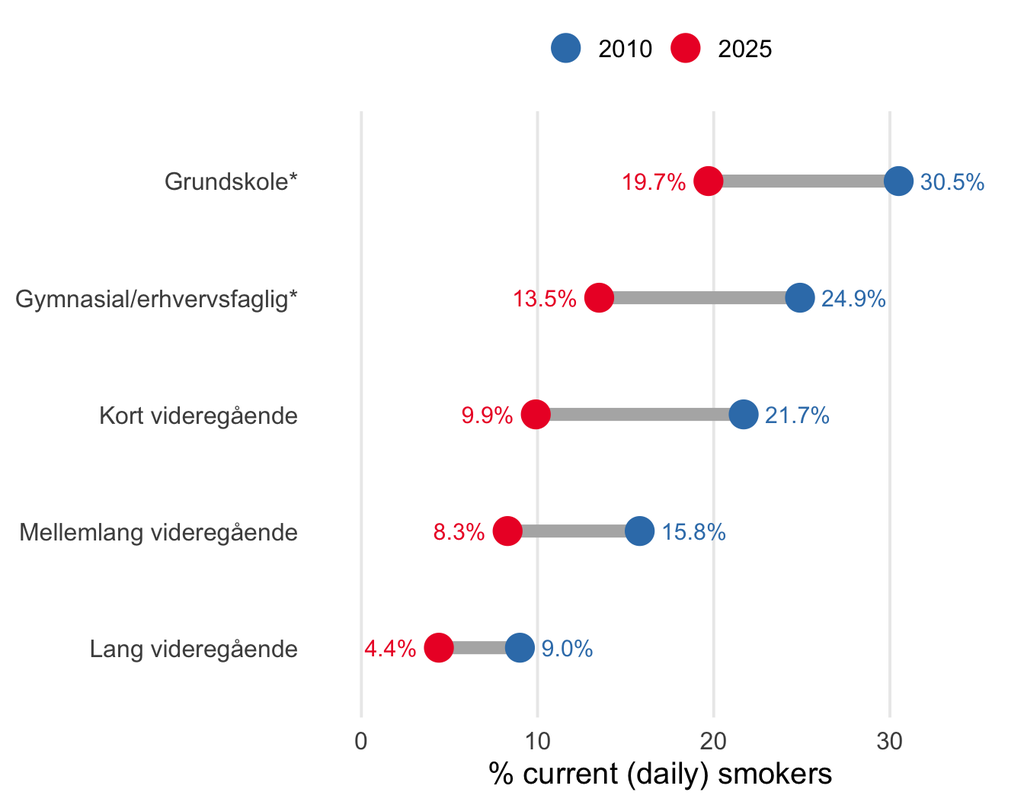

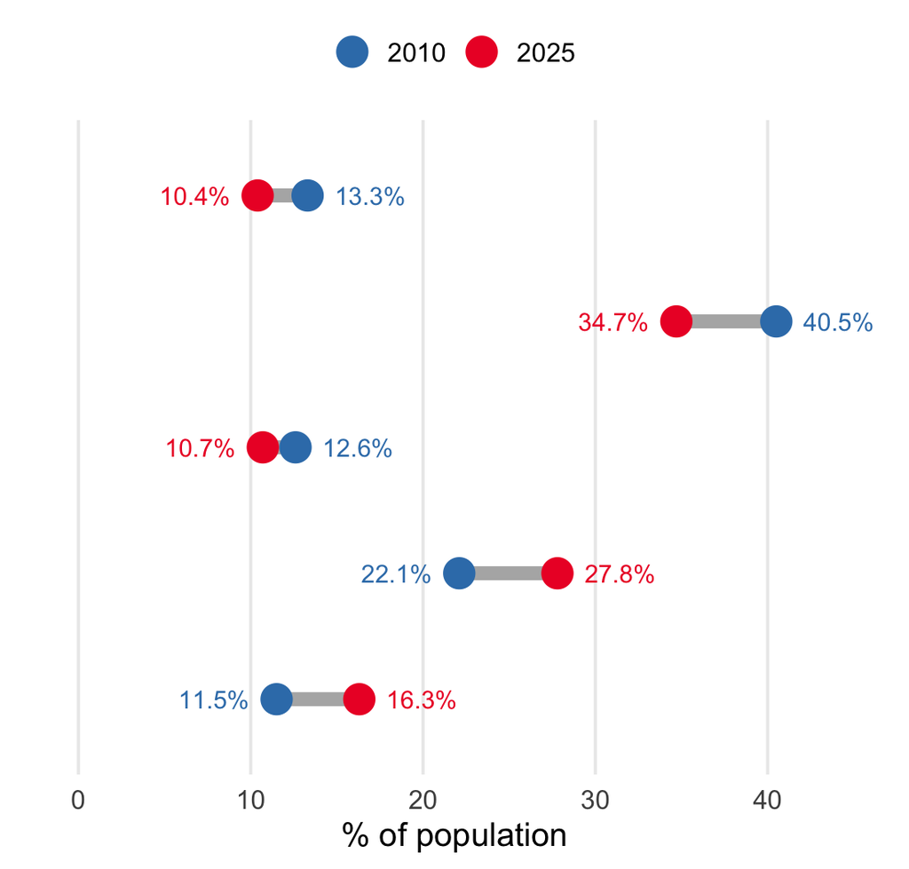

Source: Den Nationale Sundhedsprofil 2010 (Tabel 4.1.1) and 2025 (Tabel 3.1.3), Statens Institut for Folkesundhed / Sundhedsstyrelsen.

## Covered Today

**1. Kitagawa’s Decomposition**

**2. Oaxaca–Blinder Decomposition**

**3. Concentration Index Decomposition**

**4. Interventional Decomposition**

# 1. Kitagawa’s Decomposition

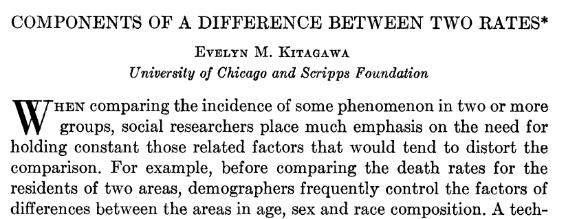

> If standardization alters a difference between two rates, it should be possible … to break it up into components attributable to the various factors for which the data were standardized.

### ‘Unpacking’ the difference between crude rates of two groups

Seminal paper by Kitagawa (1955)

[figure not shown]

## Potential consequences of ignoring composition

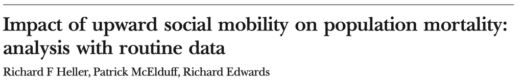

> may give a distorted view of the overall level of health inequality due to social class differentials as it does not take into account the changing distribution of social class within the whole population.

> changes in the distribution of social class across the population are an important contributor to recent reductions in mortality

Heller, McElduff, and Edwards (2002)

Group rate: $R_{i} = y_{i}/n_{i}$

Group share: $P_{i} = n_{i}/\sum_{i} n_{i}$

Crude rate: $\frac{\sum_{i=1}^{I} y_{i}}{\sum_{i=1}^{I} n_{i}} = \sum_{i=1}^{I} P_{i}R_{i}$

Standardized rate: $\frac{\sum_{i=1}^{I} y_{i}}{\sum_{i=1}^{I} s_{i}} = \sum_{i=1}^{I} S_{i}R_{i}$

where $S_{i}$ is the share of group *i* in a *standard* population ($\sum_{i} S_{i} = 1$)

### Data for crude rates

| Stratum | Pop | Count | Rate |
| --- | --- | --- | --- |
| $1$ | $n_{i}$ | $y_{i}$ | $r_{i}$ |
| $\vdots$ | $\vdots$ | $\vdots$ | $\vdots$ |
| $I$ | $N$ | $Y$ | $R$ |

| Age | Group A Share | Group A Rate | Group B Share | Group B Rate |
| --- | --- | --- | --- | --- |
| Young | 30% | 10 | 50% | 20 |
| Old | 70% | 40 | 50% | 30 |
| Crude |  | 31 |  | 25 |
| Standardized to A |  | 31 |  | 27 |

### Standardization question:

What would the $A-B$ difference be *if $B$ had $A$’s age distribution*?

## Kitagawa’s key insight

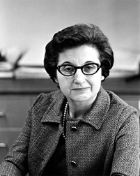

> …if the difference between two standardized rates is subtracted from the corresponding difference in crude rates…the result is a weighted average of differences between the composition of the two groups.

But what are the weights?

Crude difference = $\sum P_{Ai}R_{Ai} - \sum P_{Bi}R_{Bi}$

→ Reflects differences in both rates *and* composition

$A$-Standardized difference = $\sum P_{Ai}R_{Ai} - \sum P_{Ai}R_{Bi}$

→ Reflects *only* differences in rates ($P_{Ai}$ is constant)

Crude - Standardized = $\sum R_{Bi}(P_{Ai}-P_{Bi})$

→ Differences in composition, *weighted* by $B$s rates!

## Applying the decomposition

$$\begin{aligned}
\underbrace{\text{Rate}_A - \text{Rate}_B}_{\text{crude difference}} &= \overbrace{\sum_i \left(\frac{R_{Ai}+R_{Bi}}{2}\right)(P_{Ai}-P_{Bi})}^{\text{composition effect}} \\
&+ \underbrace{\sum_i \left(\frac{P_{Ai}+P_{Bi}}{2}\right)(R_{Ai}-R_{Bi})}_{\text{rate effect}}
\end{aligned}$$

$R_{Ai}$ is the rate for group *A* in stratum *i*.  
$P_{Ai}$ is the *i*-stratum-specific weight in group *A*.

| Age | Group A Share | Group A Rate | Group B Share | Group B Rate |
| --- | --- | --- | --- | --- |
| Young | 30% | 10 | 50% | 20 |
| Old | 70% | 40 | 50% | 30 |

| Group | Composition effect $\frac{R_{Ai}+R_{Bi}}{2}$ | Composition effect $P_{Ai}-P_{Bi}$ | Composition effect Contribution |
| --- | --- | --- | --- |
| Young | 15 | −0.20 | −3.0 |
| Old | 35 | +0.20 | +7.0 |
| Sum |  |  | +4.0 |

| Group | Rate effect $\frac{P_{Ai}+P_{Bi}}{2}$ | Rate effect $R_{Ai}-R_{Bi}$ | Rate effect Contribution |
| --- | --- | --- | --- |
| Young | 0.40 | −10 | −4.0 |
| Old | 0.60 | +10 | +6.0 |
| Sum |  |  | +2.0 |

Total = **+6.0** = crude gap (31 − 25) →67% due to composition

Rate effect (+2) = standardized gap (avg reference) (28 − 26)

## Kitagawa: does the reference group matter?

| Reference | Composition | Rate | Total |
| --- | --- | --- | --- |
| A's rates | 6.0 | 0.0 | 6.0 |
| B's rates | 2.0 | 4.0 | 6.0 |
| Average (Kitagawa) | 4.0 | 2.0 | 6.0 |

Crude gap = 31 − 25 = **6** in every row; only the split changes

Single references differ an interaction, $\sum_i (P_{Ai}-P_{Bi})(R_{Ai}-R_{Bi})$ = 4.0, which the average splits evenly

What accounts for differences in neonatal mortality rates across European countries?

GA-specific rates *or* distribution?

Implications for interventions?

[figure not shown]

Sartorius et al. (2024)

## Hiding in plain sight?

Both DK and AT similar and ~0.3 deaths per 1000 higher than “Top 3”

But *completely different* contributions to the difference

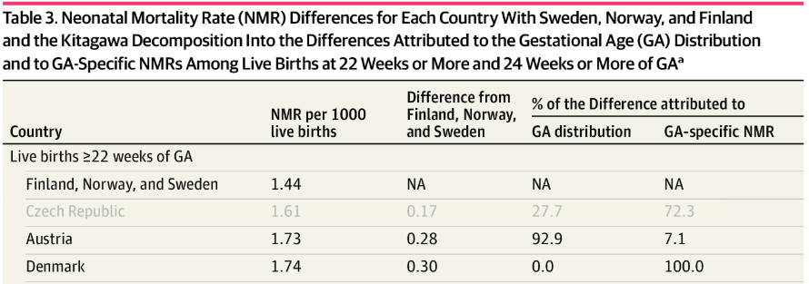

Sartorius et al. (2024)

### Denmark has much worse rates at early GA

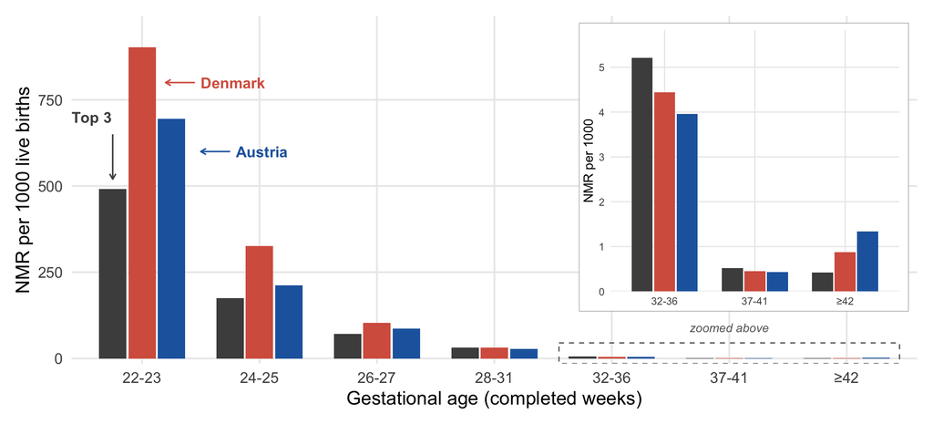

Sartorius et al. (2024)

### Austria more births at earlier GA

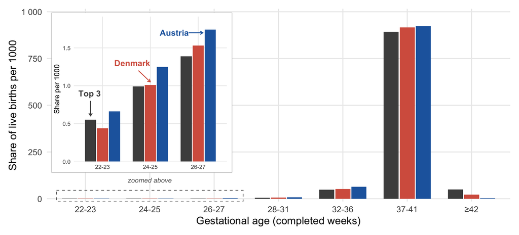

Sartorius et al. (2024)

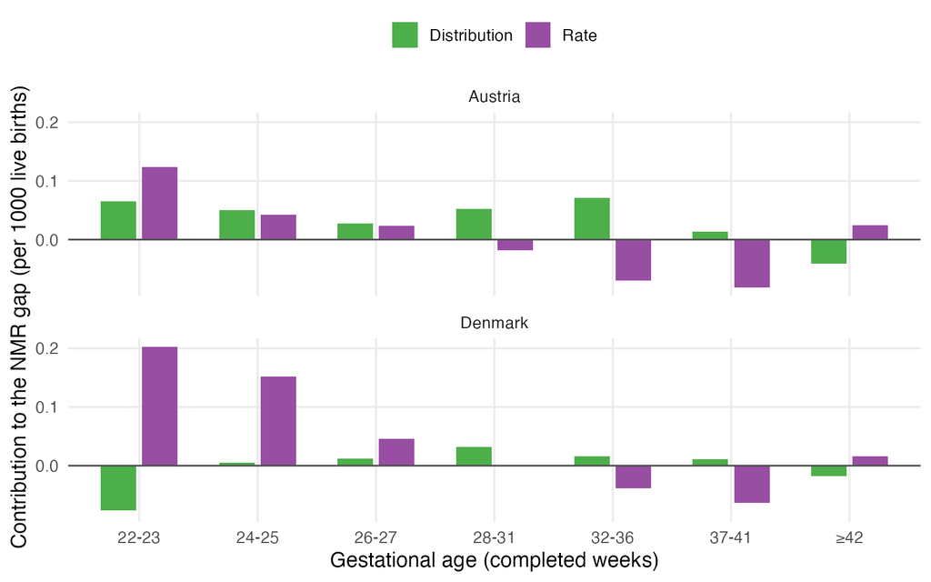

**Implications for interventions**

DK: improving care at early GA

AT: shifting the distribution of GA later

## Summary: Kitagawa’s decomposition

**When to use**  
Comparing rates across groups or over time when their composition differs

**Extensions**  
More than two groups or factors; three-part decomposition

**Caveats**  
Not causal; results depend on the strata used and on the reference weights

Kitagawa (1955); Das Gupta (1993)

## Covered Today

**1. Kitagawa’s Decomposition**

**2. Oaxaca–Blinder Decomposition**

**3. Concentration Index Decomposition**

**4. Interventional Decomposition**

# 2. Oaxaca–Blinder Decomposition

## Oaxaca-Blinder: Basic Idea

### What explains average differences in outcomes? In a regression context:

### 1. Means

#### Differences in the prevalence of determinants of outcome

### 2. Coefficients

#### Differences in the coefficient of a given determinant on the outcome (i.e., effect measure modification)

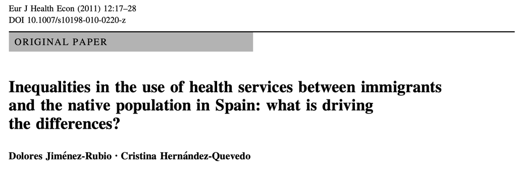

> Our findings show that unexplained factors associated to immigrant status determine to a great extent disparities in the probability of using hospital, specialist and emergency services of immigrants relative to Spaniards, while individual characteristics, in particular self-reported health and chronic conditions, are much more important in explaining the differences in the probability of using general practitioner services between immigrants and Spaniards

Jiménez-Rubio and Hernández-Quevedo (2010)

## Origins

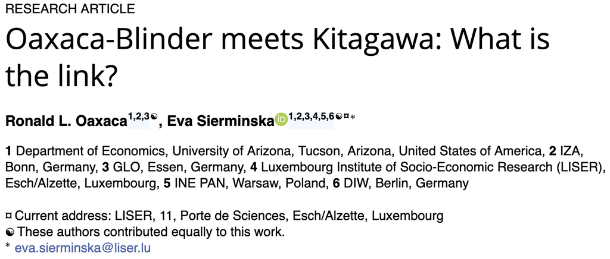

Studies by R. Oaxaca (1973) and Blinder (1973) applied regression-based decomposition methods to analyze the wage gap between men and women and between whites and blacks in the USA.

Focused on how much of wage gap was ‘explained’ by differences in observable characteristics

Recent attempts to reconcile O-B with Kitagawa (equivalent for binary outcome and categorical covariates)

R. L. Oaxaca and Sierminska (2025)

## Brief note on interpretation

Decomposition methods are based on regression analyses, and thus all of the usual caveats about good specification apply.

If regressions are purely descriptive, they reveal the associations that characterize the health inequality. Then inequality is explained in a statistical sense but implications for policies to reduce inequality are limited.

O’Donnell et al. (2008)

### Why does this work?

OLS regression line always passes through $(\bar{x}, \bar{y})$ because residuals sum to zero.

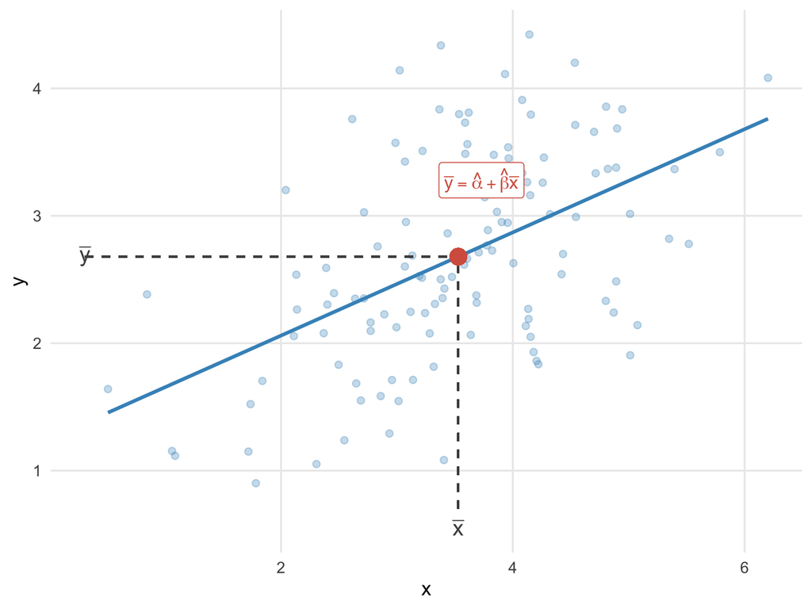

### Why does this work?

The gap decomposes into **endowments** (different $\bar{x}$, same coefficients) and **coefficients** (same $\bar{x}$, different slopes/intercepts).

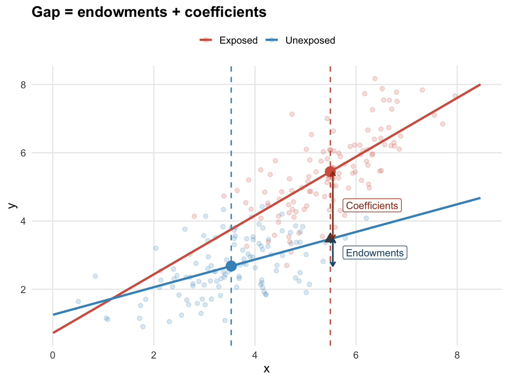

Equally valid to use the **exposed** group’s slope

Same total gap, but different split

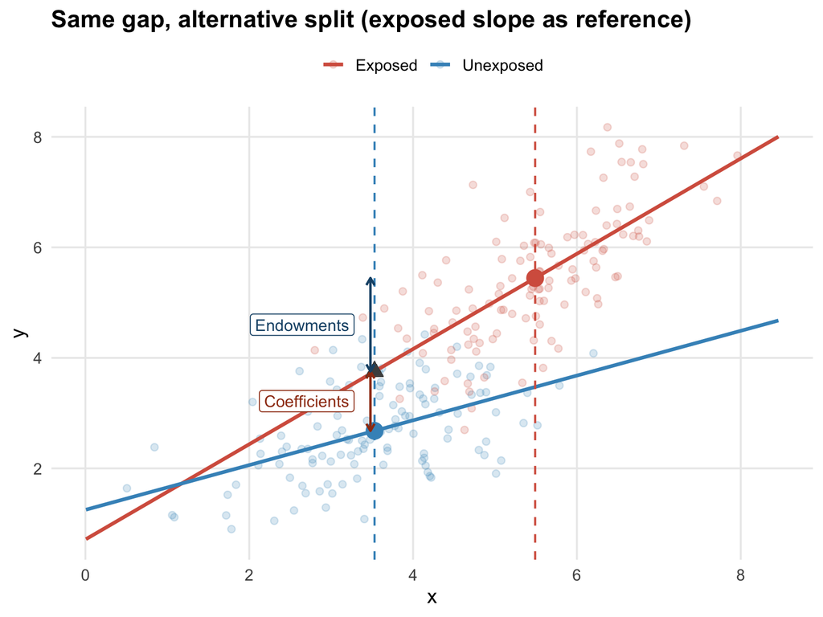

See R. Oaxaca (1973), Blinder (1973) and Cotton (1988) for details.

## Example: Educational Differences in BMI in Italy

What is the average difference in body mass index (BMI) between those with low vs. high education?

How much is due to *differing determinants* of BMI (age, gender, smoking, drinking, income)?

Any residual difference is due to education differences in the *associations* between those risk factors and BMI — i.e., the coefficients differ.

## Example data

European Social Survey Round 11, Italy (n = 1743)

Body mass index as outcome (kg/m²): `weight / height²`

Overall difference by education: High ed (ISCED 5–7) vs Low ed (ISCED 1–4)

Potential determinants (the $X$s):

- age (years)
- gender (female = 1)
- smoking (1 = current smoker)
- binge drinking (1 = monthly or more)
- married (1 = currently married)
- income decile (1–10)

## High ed BMI: 23.6, Low ed BMI: 25.2, Gap = 1.6

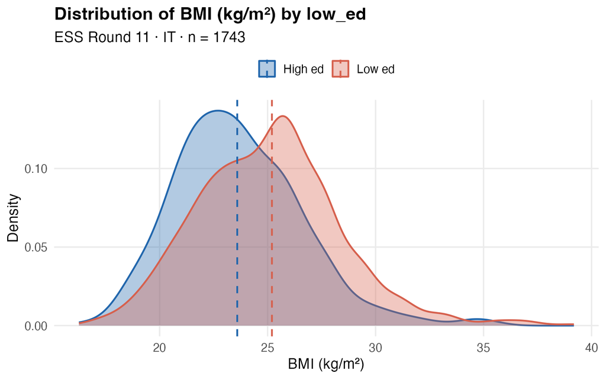

Source: Author’s calculations

## Differences in determinants

Differences in age, smoking, etc. could explain part of the BMI gap

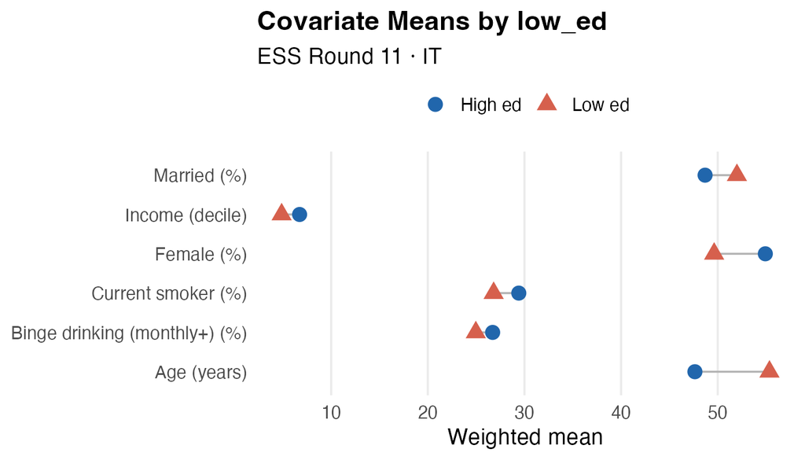

Source: Author’s calculations

## Differences in coefficients

Differences in *returns* (i.e., coefficients) form the ‘unexplained’ component

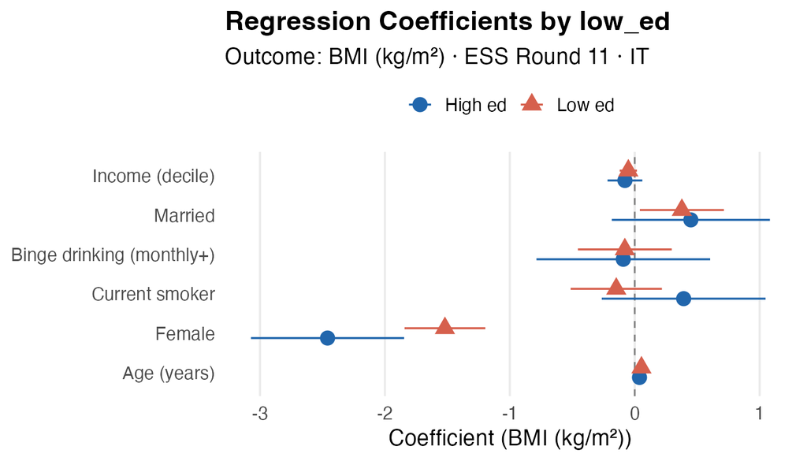

## Decomposition results: variable contributions

|  | Endowments Est | Endowments SE | Coefficients Est | Coefficients SE |
| --- | --- | --- | --- | --- |
| Total | 0.608 | 0.108 | 1.030 | 0.259 |
| Age (years) | 0.415 | 0.074 | 0.865 | 0.691 |
| Female | 0.080 | 0.051 | 0.466 | 0.181 |
| Current smoker | 0.004 | 0.008 | -0.145 | 0.115 |
| Binge drinking (monthly+) | 0.001 | 0.007 | 0.003 | 0.104 |
| Married | 0.012 | 0.016 | -0.037 | 0.208 |
| Income (decile) | 0.095 | 0.071 | 0.133 | 0.425 |
| Intercept | — | — | -0.256 | 0.837 |

Note: Low ed betas used as reference

|  | Endowments Est | Endowments SE |
| --- | --- | --- |
| Total | 0.608 | 0.108 |
| Age (years) | 0.415 | 0.074 |
| Female | 0.080 | 0.051 |
| Current smoker | 0.004 | 0.008 |
| Binge drinking (monthly+) | 0.001 | 0.007 |
| Married | 0.012 | 0.016 |
| Income (decile) | 0.095 | 0.071 |

If the low-educated had the same covariate means as the high-educated (keeping the low-educated group’s own coefficients), their BMI would be 0.608 $kg/m^2$ lower (38% of the gap).

Most of this is due to older age among the low-educated, which predicts higher BMI.

Smoking is *negative*, since smoking predicts higher BMI among the high-educated and is more common among high educated.

|  | Coefficients Est | Coefficients SE |
| --- | --- | --- |
| Total | 1.030 | 0.259 |
| Age (years) | 0.865 | 0.691 |
| Female | 0.466 | 0.181 |
| Current smoker | -0.145 | 0.115 |
| Binge drinking (monthly+) | 0.003 | 0.104 |
| Married | -0.037 | 0.208 |
| Income (decile) | 0.133 | 0.425 |
| Intercept | -0.256 | 0.837 |

## Which covariates drive the endowments?

- Variables where groups differ *and* that predict BMI contribute most
- Income and age are the biggest drivers

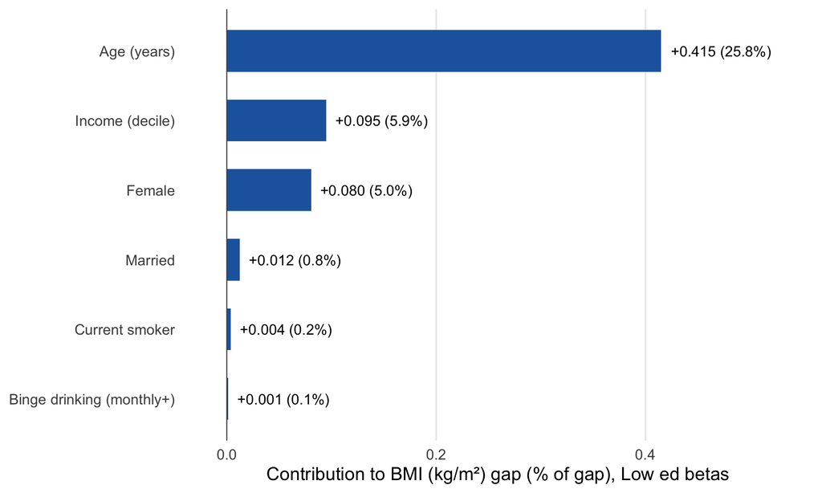

## Decomposition results: does the reference group matter?

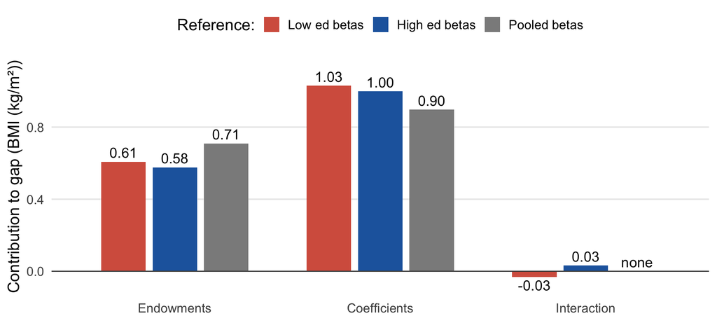

Endowments account for **36–44%** of it; interaction is negligible

## Summary: Oaxaca–Blinder decomposition

**When to use**  
Explaining average gaps with potential determinants

**Extensions**  
Nonlinear outcomes (binary, counts); pooled reference coefficients

**Caveats**  
Not causal; specification errors; reference matters for categorical covariates

R. Oaxaca (1973); Blinder (1973); Cotton (1988)

## Covered Today

**1. Kitagawa’s Decomposition**

**2. Oaxaca–Blinder Decomposition**

**3. Concentration Index Decomposition**

**4. Interventional Decomposition**

# 3. Concentration Index Decomposition

### Relative Concentration Curve

Explicitly accounts for changing composition

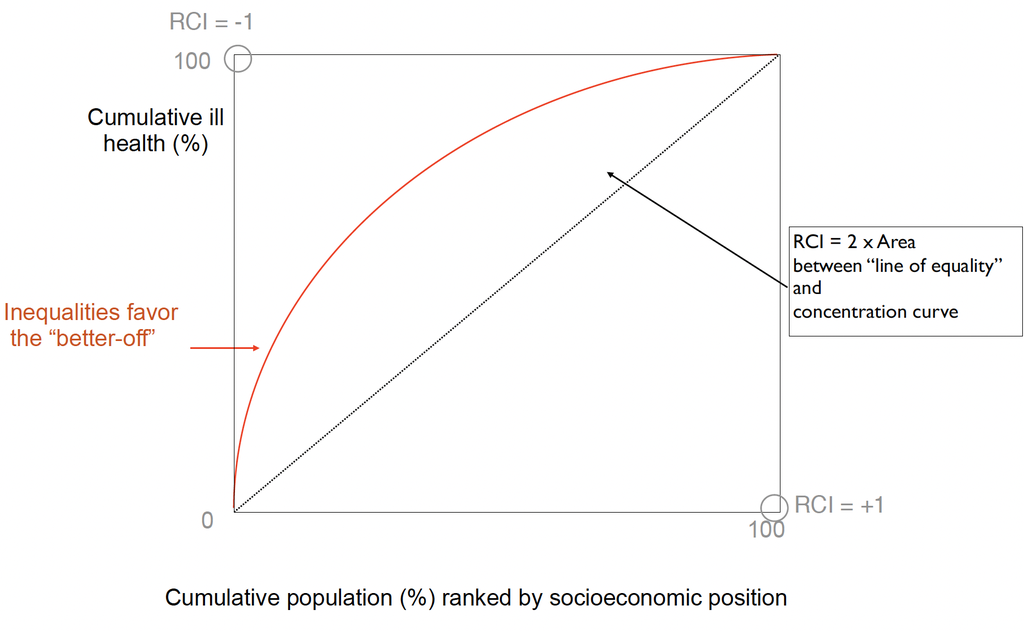

## We want to understand this:

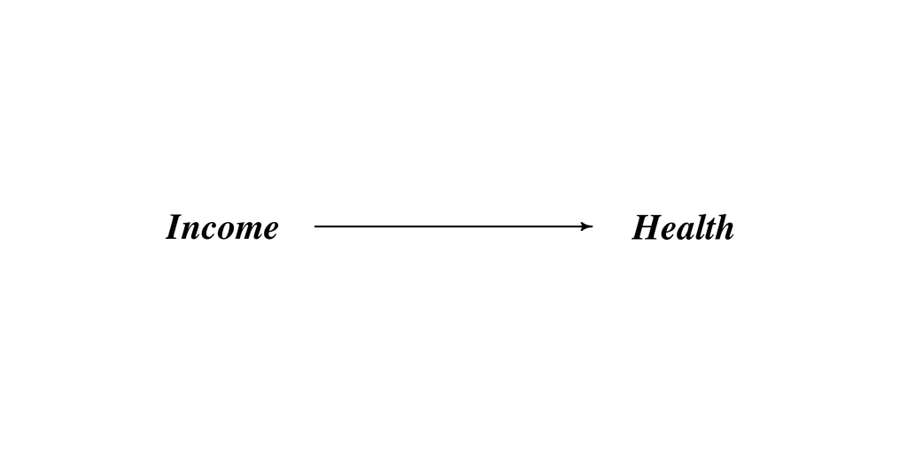

## By evaluating something like this:

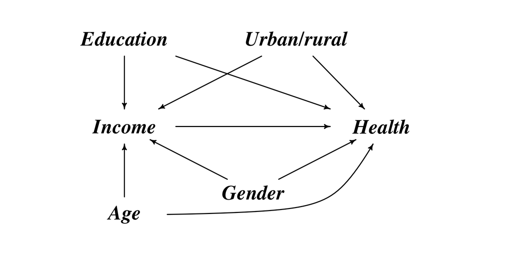

**Research Question:**

How much of inequality is due to other factors that are differential by $x$ (income) and also affect $y$ (health)?

## Relative Concentration Index

$$RCI= \frac{2}{n\mu} \sum_{i=1}^{n}y_{i}R_{i}-1$$

where

- $\mu$ is the mean of $y_{i}$ (e.g., smoking);
- $R_{i}$ is the fractional rank of the *i*th person in the socioeconomic (i.e., income) distribution.

*Decomposition*:

Develop a model for predicting $y$ using several determinants, then plug back into the $RCI$ equation

Estimates how much of the overall inequality in $y$ is due to the association between income and other factors that predict health

Kakwani, Wagstaff, and Doorslaer (1997)

### RCI Decomposition

$RCI$ is a function of health $(y_{i})$ and socioeconomic rank $(R_{i})$, i.e.
$$RCI= \frac{2}{n\mu} \sum_{i=1}^{n}{\color{red}{y_{i}}}R_{i}-1$$

Then write a regression expressing health $(y_{i})$ as a function of several $k_{i}$ determinants (e.g., age, gender, urban/rural status):
$$\color{red}{y_{i}}=\alpha + \sum{\beta_{x}x_{k_{i}}}+\epsilon_{i}$$

Wagstaff, Doorslaer, and Watanabe (2003)

### RCI Decomposition

Now re-express $RCI$ as:

$$RCI=\sum{(\beta_{k}\bar{x}_{k}/\mu)RCI_{k}}+gRCI_{e}/\mu$$

Where

- $\mu$ is the mean of $y$,
- $\bar{x}_{k}$ is the mean of determinant $x_{k}$,
- $\beta_{k}$ is the regression coefficient for $x_{k}$, and
- $RCI_{k}$ is the relative concentration index for $x_{k}$.

## Two types of ‘explained’ components

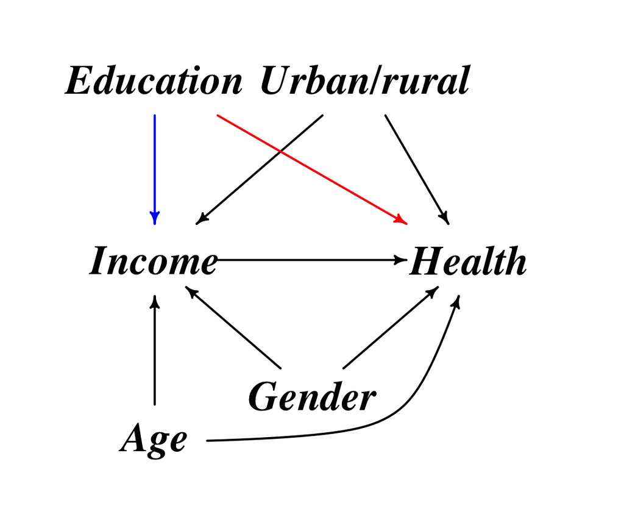

Determinant impact depends on:

1. the strength of the relationship between each factor and income $\color{blue}{RCI_{k}}$
2. the strength of the relationship between each factor and health, and its prevalence in the population (elasticity) $\color{red}{\beta_{k}\bar{x}_{k}/\mu}$

## Procedure for decomposing the Concentration Index

1. Regress $y$ (‘health’) on its determinants $(\beta_{k}x_{k})$:

$$y_{i}=\alpha + \sum{\beta_{x}x_{k_{i}}}+\epsilon_{i}$$

2. Calculate means of $y$ $(\mu)$ and all $x_{k}$ determinants
3. Calculate ($RCI$) for health *and* for each determinant $(RCI_{k})$, i.e., use each $x_{k}$ as the “outcome” and estimate a $RCI$ for age, education, etc.

## Procedure for decomposing the Concentration Index

4. Absolute contribution: for each $x$ multiply ‘elasticity’ by its concentration index $(RCI_{k})$:

$$(\beta_{k}\bar{x}_{k}/\mu)RCI_{k}$$

5. Calculate the % contribution of each determinant:

$$[(\beta_{k}\bar{x}_{k}/\mu)RCI_{k}]/RCI$$